# MODELOS PREDICTIVOS BASADOS EN REDES NEURONALES

## Comprobación de que nuestro entorno ejecuta con GPU

```python
import pandas as pd
import numpy as np
import matplotlib.pyplot as plt
import os
os.environ['TF_CPP_MIN_LOG_LEVEL'] = '2'  # 0 = all, 1 = INFO, 2 = WARNING, 3 = ERROR

import tensorflow as tf
from tensorflow.keras.optimizers import Adam
from keras.layers import LSTM, Flatten, Input, Dense, Dropout, Conv1D, LayerNormalization, MultiHeadAttention, Embedding, GlobalAveragePooling1D
from keras.callbacks import EarlyStopping, ModelCheckpoint, ReduceLROnPlateau, Callback
from keras.losses import MeanSquaredError
from keras.models import Sequential, Model, load_model
from keras.regularizers import l1_l2
from sklearn.metrics import mean_squared_error, mean_absolute_error, r2_score, median_absolute_error
from sklearn.model_selection import train_test_split, KFold
from sklearn.preprocessing import StandardScaler
from hyperopt import hp, STATUS_OK, fmin, tpe, Trials, space_eval
from functools import partial
from joblib import dump, load
from tqdm import tqdm
import time
import warnings
warnings.filterwarnings('ignore')

# Obtenemos la lista de dispositivos utilizables
visible_devices = tf.config.experimental.list_physical_devices()

if len(visible_devices) == 0:
    print("No se detectaron dispositivos físicos (GPU/TPU).")
else:
    for device in visible_devices:
        print(f"Dispositivo detectado: {device.name}")
print("TF version   : ", tf.__version__)
```

```
Dispositivo detectado: /physical_device:CPU:0
Dispositivo detectado: /physical_device:GPU:0
TF version   :  2.15.0
```

```python
df = pd.read_csv(f"./DatosViviendas.csv")
print('Tamaño dataframe: ', df.shape)
```

```
Tamaño dataframe:  (51585, 16)
```

# Redes Neuronales Densas (DNN)

Preparamos los datos para poder utilizarlos con una DNN:

```python
# Dividimos el dataset en variables características (X) y objetivo (y)
X = df.drop('Precio', axis=1)
y = df['Precio']

# Normalizamos los datos
scaler = StandardScaler()
X = scaler.fit_transform(X)
```

Vamos a definir un método de evaluación cruzada que nos permita, dada una arquitectura de red neuronal, determinar en qué medida esta se ajusta a nuestros datos de forma efectiva. Este método basado en kfold no estará diseñado para encontrar el mejor modelo posible, si no para darnos una estimación de cómo de bien funciona la red diseñada con nuestros datos y así poder determinar la mejor arquitectura de red posible. Una vez obtenida esta, habría que realizar un entrenamiento más exhaustivo con los mejores hiperparámetros posibles.

```python
def kfold_mse_evaluation(x, y, input_shape, n=1000, splits=5):
    # Validación cruzada
    kf = KFold(n_splits=splits, shuffle=True, random_state=42)

    # Inicialización de listas para almacenar resultados
    mse_scores = []
    best_mse = float('inf')

    for train_index, test_index in tqdm(kf.split(x)):
        X_train, X_test = x[train_index], x[test_index]
        y_train, y_test = y.iloc[train_index], y.iloc[test_index]

        # Construimos y entrenamos el modelo
        model = build_model(input_shape)
        history = model.fit(X_train, y_train, epochs=n, batch_size=256, validation_split=0.2, verbose=0)

        # Evaluamos el modelo
        mse = model.evaluate(X_test, y_test, verbose=1)
        mse_scores.append(mse)

        if mse < best_mse:
            best_mse = mse
            best_history = history

    # Calculamos el MSE promedio a través de las iteraciones de validación cruzada
    mean_mse = np.mean(mse_scores)

    return mean_mse, best_history
```

```python
def evaluacion(model, X_test, y_test):
    metricas = {}
    # Predecimos los valores de 'Precio' para el conjunto de prueba
    y_pred = model.predict(X_test)

    # MSE - Error Cuadrático Medio
    metricas['MSE'] = mean_squared_error(y_test, y_pred)

    # RMSE - Raíz del Error Cuadrático Medio
    metricas['RMSE'] = np.sqrt(metricas['MSE'])

    # MAE - Error Absoluto Medio
    metricas['MAE'] = mean_absolute_error(y_test, y_pred)

    # MedAE - Mediana del Error Absoluto
    metricas['MedAE'] = median_absolute_error(y_test, y_pred)

    # Coeficiente de Determinación, R²
    metricas['R2'] = r2_score(y_test, y_pred)

    # MAPE - Error Porcentual Absoluto Medio
    y_pred = y_pred.flatten() # Aseguramos que sean unidimensionales
    y_test = np.array(y_test).flatten() if isinstance(y_test, pd.Series) else y_test

    metricas['MAPE'] = np.mean(np.abs((y_test - y_pred) / y_test)) * 100

    # Imprimir resultados
    print("MSE:", metricas['MSE'])
    print("RMSE:", metricas['RMSE'])
    print("MAE:", metricas['MAE'])
    print("R²:", metricas['R2'])
    print("MAPE:", metricas['MAPE'], "%")

    return metricas
```

Implementamos ahora un método para visualizar el progreso en el aprendizaje y poder visualizar si este se está produciendo de manera efectiva:

```python
def plot_history(history):
    plt.figure(figsize=(14, 5))
    plt.subplot(1, 2, 1)
    plt.plot(history.history['loss'], label='Train Loss')
    plt.plot(history.history['val_loss'], label='Validation Loss')
    plt.title('Loss Over Epochs')
    plt.xlabel('Epochs')
    plt.ylabel('Loss')
    plt.legend()
    plt.show()
```

```python
# Definimos la arquitectura de la red neuronal con regularización
def build_model(input_shape, l1=1e-5, l2=1e-4, dropout_rate=0.3):
    model = Sequential()
    model.add(Dense(128, activation='relu', input_shape=input_shape,
                    kernel_regularizer=l1_l2(l1=l1, l2=l2)))
    model.add(Dropout(dropout_rate))
    model.add(Dense(64, activation='relu', kernel_regularizer=l1_l2(l1=l1, l2=l2)))
    model.add(Dropout(dropout_rate))
    model.add(Dense(32, activation='relu', kernel_regularizer=l1_l2(l1=l1, l2=l2)))
    model.add(Dropout(dropout_rate))
    model.add(Dense(16, activation='relu', kernel_regularizer=l1_l2(l1=l1, l2=l2)))
    model.add(Dense(1))  # Capa de salida para regresión
    model.compile(optimizer='adam', loss='mae')

    return model
```

```python
mean_mse_dnn, dnn_history = kfold_mse_evaluation(X, y, (X.shape[1],))
print(f'Mean MSE from Cross-Validation: {mean_mse_dnn}')
```

```
0it [00:00, ?it/s]
```

```
1it [12:45, 765.54s/it]
```

```
2it [25:13, 755.05s/it]
```

```
3it [37:55, 758.47s/it]
```

```
4it [50:21, 753.53s/it]
```

```
5it [1:03:04, 756.81s/it]
```

```
Mean MSE from Cross-Validation: 13055202892.8
```

```python
dnn_history.history.keys()
```

```
dict_keys(['loss', 'val_loss'])
```

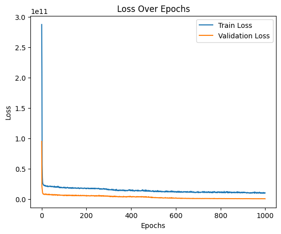

```python
# Representación del acc-loss
plot_history(dnn_history)
```

# Redes Neuronales Convolucionales (CNN)

Aunque las CNN están originalmente diseñadas para el tratamiento de imágenes, lo cierto es que también pueden ser utilizadas en otros ámbitos como la predicción de series temporales o la estimación de atributos objetivo en base a las características, como es nuestro caso con el precio de la vivienda. Para poder llevar a cabo esta técnica y poder utilizar una capa Conv1D, la clave será tratar cada una de las características como un canal con formato unidimensional.

Para entender cómo funcionan las capas Conv1D y cómo se pueden aplicar a datos que no son imágenes, como series temporales o datos tabulares, es útil revisar primero qué hacen las capas convolucionales y luego cómo se adaptan a estos contextos:

#### Capas Convolucionales en el Contexto de Imágenes

En el procesamiento de imágenes, una capa convolucional (como Conv2D en el caso de las CNN) aplica una serie de filtros a la imagen para extraer características. Estos filtros se deslizan a través de la imagen (2D), procesando la información espacial. En las imágenes, cada "canal" suele corresponder a un color (por ejemplo, rojo, verde y azul en imágenes RGB).

#### Capas Convolucionales para Datos Unidimensionales (Conv1D)

En el caso de los datos unidimensionales, como las series temporales o los datos tabulares, utilizamos capas Conv1D. Aquí, los filtros se deslizan a lo largo de una sola dimensión. En lugar de tratar la información espacial como en las imágenes, se tratan secuencias de datos o características individuales.

Cuando aplicamos Conv1D a datos tabulares (como en nuestro caso de estimación de precios de viviendas), tratamos cada característica (o columna en nuestros datos tabulares) como si fuera un "canal" en el sentido de procesamiento de imágenes. El filtro de la capa Conv1D se deslizará a través de cada una de estas características, buscando patrones útiles para la tarea de predicción.

```python
# Dividimos el dataset en variables características (X) y objetivo (y)
X = df.drop('Precio', axis=1)
y = df['Precio']

# Redimensionamos X
X = np.expand_dims(X, axis=1)
```

```python
# Definimos la arquitectura de la red neuronal con regularización
def build_model(input_shape, l1=1e-5, l2=1e-4, dropout_rate=0.3):
    model = Sequential()

    # Capa Conv1D
    # Tratando cada característica como un canal en un formato unidimensional
    model.add(Conv1D(filters=64, kernel_size=1, activation='relu', input_shape=input_shape,
                     kernel_regularizer=l1_l2(l1=l1, l2=l2)))
    model.add(Dropout(dropout_rate))

    # Segunda capa Conv1D
    model.add(Conv1D(filters=32, kernel_size=1, activation='relu',
                     kernel_regularizer=l1_l2(l1=l1, l2=l2)))
    model.add(Dropout(dropout_rate))

    # Aplanamos los datos para transición de Conv1D a Dense
    model.add(Flatten())

    # Capa Densa
    model.add(Dense(32, activation='relu', kernel_regularizer=l1_l2(l1=l1, l2=l2)))

    # Capa Densa
    model.add(Dense(16, activation='relu', kernel_regularizer=l1_l2(l1=l1, l2=l2)))

    # Capa de Salida para regresión
    model.add(Dense(1))

    # Compilar el modelo
    model.compile(optimizer='adam', loss='mae')

    return model
```

```python
mean_mse_cnn, cnn_history = kfold_mse_evaluation(X, y, X.shape[1:])
print(f'Mean MSE from Cross-Validation: {mean_mse_cnn}')
```

```
0it [00:00, ?it/s]
```

```
1it [11:00, 660.61s/it]
```

```
2it [22:09, 665.59s/it]
```

```
3it [34:43, 705.69s/it]
```

```
4it [46:46, 712.77s/it]
```

```
5it [59:24, 712.83s/it]
```

```
Mean MSE from Cross-Validation: 25563198668.8
```

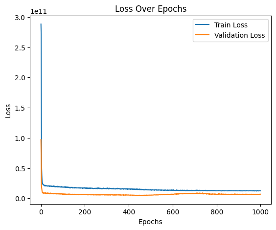

```python
# Representación del acc-loss
plot_history(cnn_history)
```

# Redes Neuronales Recurrentes (RNN) y LSTM

Estas redes están principalmente orientadas al tratamiento de series temporales. Es por esto que para utilizarlas ordenaremos y transformaremos nuestros datos para que puedan ser tratados como tal. Aunque estas redes podrían encajar mucho mejor en otro tipo de análisis, como colapsar los datos obtenidos a nivel de día e intentar predecir el precio medio del mercado a largo plazo, vamos a comprobar su comportamiento con nuestro conjunto de datos y objetivo.

```python
# Concatenar las columnas 'Año', 'Mes' y 'Dia' en una sola cadena
df['Fecha'] = pd.to_datetime(df['Año'].astype(str) + '-' + df['Mes'].astype(str) + '-' + df['Dia'].astype(str))

# Ordenamos por fecha
df_sorted = df.sort_values(by='Fecha')
```

```python
# Dividimos el dataset en variables características (X) y objetivo (y)
X = df_sorted.drop(['Precio', 'Fecha'], axis=1)
y = df_sorted['Precio']

# Redimensionamos X
X = np.expand_dims(X, axis=1)
```

```python
# Definimos la arquitectura de la red neuronal con regularización
def build_model(input_shape, l1=1e-5, l2=1e-4, dropout_rate=0.3):
    model = Sequential()

    # Capa LSTM
    model.add(LSTM(128, return_sequences=True, input_shape=input_shape,
                   kernel_regularizer=l1_l2(l1=l1, l2=l2)))
    model.add(Dropout(dropout_rate))

    model.add(LSTM(64, kernel_regularizer=l1_l2(l1=l1, l2=l2)))
    model.add(Dropout(dropout_rate))

    # Capas Densas
    model.add(Dense(32, activation='relu', kernel_regularizer=l1_l2(l1=l1, l2=l2)))

    # Capas Densas
    model.add(Dense(16, activation='relu', kernel_regularizer=l1_l2(l1=l1, l2=l2)))

    # Capa de salida para regresión
    model.add(Dense(1))

    # Compilación del Modelo
    model.compile(optimizer='adam', loss='mae')

    return model
```

```python
mean_mse_lstm, lstm_history = kfold_mse_evaluation(X, y, X.shape[1:])
print(f'Mean MSE from Cross-Validation: {mean_mse_lstm}')
```

```
0it [00:00, ?it/s]
```

```
1it [18:58, 1138.38s/it]
```

```
2it [38:26, 1155.83s/it]
```

```
3it [57:15, 1143.50s/it]
```

```
4it [1:16:26, 1146.42s/it]
```

```
5it [1:35:26, 1145.32s/it]
```

```
Mean MSE from Cross-Validation: 20095000780.8
```

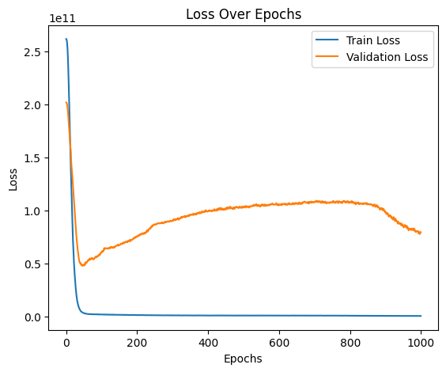

```python
# Representación del acc-loss
plot_history(lstm_history)
```

Como se esperaba, los resultados obtenidos no son del todo buenos, pues esta arquitectura de red se comporta mejor en otro tipo de análisis.

# Modelo Híbrido (CNN - RNN - DNN)

Vamos a probar un modelo híbrido donde combinamos los tres modelos vistos anteriormente. Aunque, al estar basados de nuevo en redes más orientadas a procesamiento de imágenes, y a redes orientadas al tratamiento de series temporales, vamos a comprobar cómo se comporta este modelo híbrido y si puede ofrecernos alguna mejora.

```python
# Definimos la arquitectura de la red neuronal con regularización
def build_model(input_shape, l1=1e-5, l2=1e-4, dropout_rate=0.3):
    model = Sequential()

    # Capa Conv1D - Extracción de características
    model.add(Conv1D(filters=64, kernel_size=1, activation='relu', input_shape=input_shape,
                     kernel_regularizer=l1_l2(l1=l1, l2=l2)))
    model.add(Dropout(dropout_rate))

    # Capa LSTM - Captura de dependencias temporales/secuenciales
    model.add(LSTM(64, return_sequences=False, kernel_regularizer=l1_l2(l1=l1, l2=l2)))
    model.add(Dropout(dropout_rate))

    # Capa Flatten para transición de LSTM a Dense
    model.add(Flatten())

    # Capas Densas - Integración y Predicción
    model.add(Dense(32, activation='relu', kernel_regularizer=l1_l2(l1=l1, l2=l2)))
    model.add(Dense(16, activation='relu', kernel_regularizer=l1_l2(l1=l1, l2=l2)))
    model.add(Dense(1))  # Capa de salida para regresión

    # Compilación del Modelo
    model.compile(optimizer='adam', loss='mae')

    return model
```

```python
mean_mse_mh, mh_history = kfold_mse_evaluation(X, y, X.shape[1:])
print(f'Mean MSE from Cross-Validation: {mean_mse_mh}')
```

```
0it [00:00, ?it/s]
```

```
1it [15:03, 903.05s/it]
```

```
2it [29:45, 891.13s/it]
```

```
3it [44:50, 897.42s/it]
```

```
4it [1:00:12, 906.94s/it]
```

```
5it [1:15:31, 906.33s/it]
```

```
Mean MSE from Cross-Validation: 203805658316.8
```

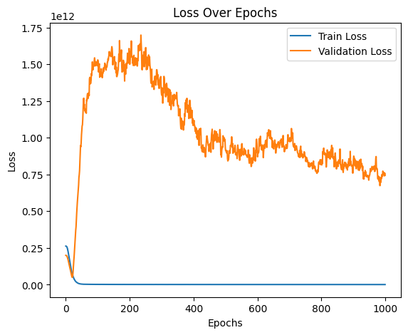

```python
# Representación del acc-loss
plot_history(mh_history)
```

Aparentemente, empeora los resultados obtenidos en los dos modelos anteriores, por lo que concluimos que un enfoque híbrido no sería adecuado para nuestro modelo.

# Transformers

Aunque originalmente están diseñados para optimizar el aprendizaje en modelos relacionados con procesamiento de txtos, análisis de sentimientos y NLP en general, pueden llegar a ser utilizables también en este tipo de modelos de estimación de valores en base a las características. Por ello vamos a probar cómo se comportan y ver si pueden mejorar los resultados obtenidos hasta ahora.

En nuestro modelo, cada muestra de los datos tabulares (características de una vivienda) se transforma primero a través de una capa densa, y luego estas representaciones son procesadas por la atención multi-cabeza. Esto permite que el modelo aprenda cómo diferentes características de una vivienda (como tamaño, ubicación, número de habitaciones) interactúan y afectan el precio de la vivienda.

Este modelo puede aportar diversas ventajas, aunque no es común, usar Transformers en datos tabulares puede ser útil para capturar relaciones complejas y no lineales entre características. De igual forma, los Transformers son modelos muy potentes y flexibles, lo que les permite adaptarse a una variedad de tareas más allá del procesamiento de lenguaje.

Por otro lado, estos modelos suelen tener un coste computacional mucho más elevado y no tener por qué ser óptimos en análisis como el que estamos llevando a cabo.

```python
# Definimos la arquitectura de la red neuronal con regularización
def build_model(input_shape, num_heads=4, dropout_rate=0.2, dff=64):
    # Entrada
    inputs = Input(shape=input_shape)

    # Capa de embedding para datos tabulares
    x = Dense(dff, activation='relu')(inputs)
    x = Dropout(dropout_rate)(x)

    # Capa de atención
    attention_output = MultiHeadAttention(num_heads=num_heads, key_dim=dff)(x, x)

    # Capa de feed-forward
    x = Dense(dff, activation='relu')(attention_output)
    x = Dropout(dropout_rate)(x)

    # Capa de normalización
    x = LayerNormalization(epsilon=1e-6)(x)

    # Pooling y salida
    x = GlobalAveragePooling1D()(x)
    outputs = Dense(1)(x)  # Salida para regresión

    model = Model(inputs=inputs, outputs=outputs)
    model.compile(optimizer='adam', loss='mae')

    return model
```

```python
mean_mse_t, t_history = kfold_mse_evaluation(X, y, X.shape[1:])
print(f'Mean MSE from Cross-Validation: {mean_mse_t}')
```

```
0it [00:00, ?it/s]
```

```
1it [17:02, 1022.02s/it]
```

```
2it [33:53, 1015.71s/it]
```

```
3it [50:27, 1005.92s/it]
```

```
4it [1:07:12, 1005.67s/it]
```

```
5it [1:23:40, 1004.09s/it]
```

```
Mean MSE from Cross-Validation: 27962270515.2
```

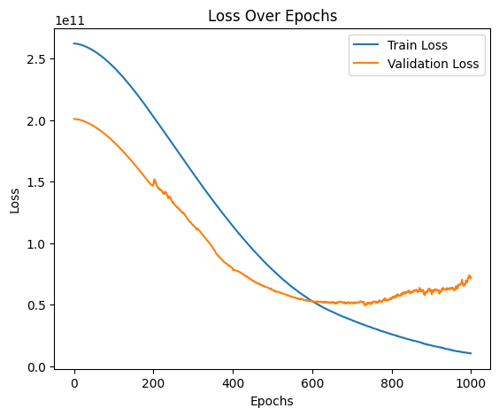

```python
# Representación del acc-loss
plot_history(t_history)
```

Como ya se vaticinaba, el claro enfoque que tienen este tipo de redes hacia los problemas de Procesamiento de Lenguaje Natural (NLP), hacen que no sean del todo adecuados para nuestros datos y nuestro enfoque de análisis. Aunque los resultados no son malos, podemos concluir que no mejora lo obtenido por los modelos probados hasta ahora.

## ANÁLISIS COMPARATIVO PARA DETERMINAR LA MEJOR ARQUITECTURA:

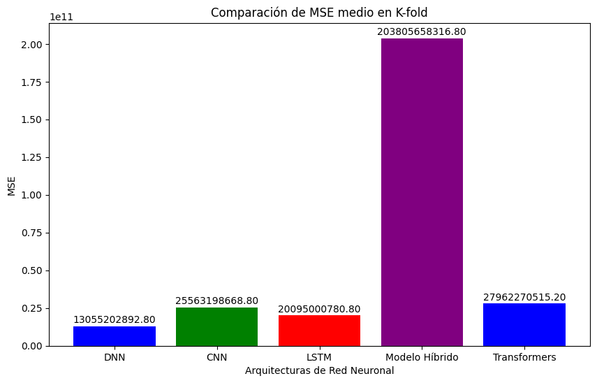

```python
valores = [mean_mse_dnn, mean_mse_cnn, mean_mse_lstm, mean_mse_mh, mean_mse_t]
nombres_modelos = ['DNN', 'CNN', 'LSTM', 'Modelo Híbrido', 'Transformers']

# Creamos la gráfica de barras
plt.figure(figsize=(10, 6))
plt.bar(nombres_modelos, valores, color=['blue', 'green', 'red', 'purple'])
plt.title(f'Comparación de MSE medio en K-fold')
plt.ylabel('MSE')
plt.xlabel('Arquitecturas de Red Neuronal')
for i, v in enumerate(valores):
    plt.text(i, v + max(valores)*0.01, f"{v:.2f}", ha='center')
plt.show()
```

Como se puede apreciar, parece que todos los modelos proporcionan unos resultados similares, a excepción del construido de forma híbrida, el cuál ha tenido un enorme sobreajuste, y esto ha resultado en que no sea capaz de predecir sobre nuestro conjunto de test de manera eficiente.

Entre el resto el que aparentemente cuenta con más potencial es el modelo DNN, seguido en la distancia por la red LSTM. Sin embargo, todos han mostrado un desempeño aceptable más allá del modelo hibrído, así que realizaremos la optimización bayesiana combinándola con validación cruzada para evitar el sobreajuste sobre todos ellos y con esto determinaremos cuál es realmente el meor.

# Busqueda de mejores Hiperparámetros

Una vez realizada la optimización bayesiana combinada con la validación cruzada, se han obtenido los mejores hiperparámetros posibles. A partir de aquí se ha vuelto a usar train_test_split para dividir nuestros datos en conjuntos de test, validación y entrenamiento, en una proporción 0.8, 0.1 y 0.1 respectivamente, y se han entrenado los modelos definitivos con los mejores hiperparámetros, siendo el objetivo minimizar la función de pérdida para el conjunto de validación.

### Modelo DNN

Definimos el espacio de hiperparámetros.

```python
space = {
    'units_1': hp.choice('units_1', [128, 256, 512]),
    'units_2': hp.choice('units_2', [64, 128, 256]),
    'units_3': hp.choice('units_3', [32, 64, 128]),
    'units_4': hp.choice('units_4', [16, 32, 64]),
    'dropout_rate': hp.uniform('dropout_rate', 0.1, 0.5),
    'l1': hp.loguniform('l1', -8, -2),
    'l2': hp.loguniform('l2', -8, -2),
    'learning_rate': hp.loguniform('learning_rate', -5, 0)
}
```

Construimos el modelo.

```python
def build_model_dnn(input_shape, units_1, units_2, units_3, units_4, dropout_rate, l1, l2, learning_rate):
    model = Sequential()
    model.add(Dense(units_1, activation='relu', input_shape=input_shape, kernel_regularizer=l1_l2(l1=l1, l2=l2)))
    model.add(Dropout(dropout_rate))
    model.add(Dense(units_2, activation='relu', kernel_regularizer=l1_l2(l1=l1, l2=l2)))
    model.add(Dropout(dropout_rate))
    model.add(Dense(units_3, activation='relu', kernel_regularizer=l1_l2(l1=l1, l2=l2)))
    model.add(Dropout(dropout_rate))
    model.add(Dense(units_4, activation='relu', kernel_regularizer=l1_l2(l1=l1, l2=l2)))
    model.add(Dense(1))  # Capa de salida para regresión
    model.compile(optimizer=Adam(learning_rate=learning_rate), loss='mae')
    return model
```

Preparamos los datos para el entrenamiento del modelo.

```python
input_shape = (X.shape[1],)

# Dividimos los datos en conjuntos de entrenamiento y prueba
X_train, X_test, y_train, y_test = train_test_split(X, y, test_size=0.1, shuffle=True, random_state=42)
X_train, X_val, y_train, y_val = train_test_split(X_train, y_train, test_size=0.1, shuffle=True, random_state=42)
```

Definimos la función objetivo e iniciamos la optimización bayesiana.

```python
def objective_dnn(params, x, y):
    n = 500
    early_stopping = EarlyStopping(monitor='val_loss', patience=50, restore_best_weights=True)
    model = build_model_dnn(input_shape, params['units_1'], params['units_2'], params['units_3'], params['units_4'],
                        params['dropout_rate'], params['l1'], params['l2'], params['learning_rate'])

    # Realizamos validación cruzada y calculamos el error medio
    kf = KFold(n_splits=5, shuffle=True, random_state=42)
    mae_scores = []

    for train_index, test_index in kf.split(x):
        X_train, X_test = x[train_index], x[test_index]
        y_train, y_test = y.iloc[train_index], y.iloc[test_index]

        model.fit(X_train, y_train, epochs=n, batch_size=256, validation_split=0.2, verbose=0, callbacks=[early_stopping])

        # Evaluamos el modelo
        y_pred = model.predict(X_test, verbose=0)
        mae = mean_absolute_error(y_test, y_pred)
        mae_scores.append(mae)

    # Calculamos el MSE promedio a través de las iteraciones de validación cruzada
    mean_mae = np.mean(mae_scores)

    return {'loss': mean_mae, 'status': STATUS_OK}
```

```python
objective_with_data_dnn = partial(objective_dnn, x=X, y=y)

trials_dnn = Trials()
best_dnn = fmin(fn=objective_with_data_dnn,
            space=space,
            algo=tpe.suggest,
            max_evals=50,
            trials=trials_dnn)

best_dnn_params = space_eval(space, best_dnn)
print(best_dnn_params)
```

```
{'dropout_rate': 0.10177874426876955, 'l1': 0.024009413293527126, 'l2': 0.007465943823826413, 'learning_rate': 0.009109566468356005, 'units_1': 256, 'units_2': 128, 'units_3': 128, 'units_4': 32}
```

Evaluamos los resultados.

```python
# Obtenemos todos los MSE registrados en las pruebas
mse_values_dnn = [x['loss'] for x in trials_dnn.results]

# Encontramos el mejor MSE
best_mse_dnn = min(mse_values_dnn)

print(f"El mejor MSE obtenido es: {best_mse_dnn}")
```

```
El mejor MSE obtenido es: 65032.24958169767
```

```python
best_dnn_model = build_model_dnn(input_shape, **best_dnn_params)
```

### Transformers

```python
# Redimensionamos X
X = np.expand_dims(X, axis=1)

input_shape = X.shape[1:]
```

```python
# Dividimos los datos en conjuntos de entrenamiento y prueba
X_train, X_test, y_train, y_test = train_test_split(X, y, test_size=0.1, shuffle=True, random_state=42)
X_train, X_val, y_train, y_val = train_test_split(X_train, y_train, test_size=0.1, shuffle=True, random_state=42)
```

```python
space_t = {
    'num_heads': hp.choice('num_heads', [2, 4, 8]),
    'dropout_rate': hp.uniform('dropout_rate', 0.1, 0.5),
    'dff': hp.choice('dff', [32, 64, 128, 256]),
    'l1': hp.loguniform('l1', -8, -2),
    'l2': hp.loguniform('l2', -8, -2),
    'learning_rate': hp.loguniform('learning_rate', -5, 0)
}
```

```python
# Definimos la arquitectura de la red neuronal con regularización
def build_t_model(input_shape, num_heads, dropout_rate, dff, l1, l2, learning_rate):
    # Entrada
    inputs = Input(shape=input_shape)

    # Capa de embedding para datos tabulares
    x = Dense(dff, activation='relu', kernel_regularizer=l1_l2(l1=l1, l2=l2))(inputs)
    x = Dropout(dropout_rate)(x)

    # Capa de atención
    attention_output = MultiHeadAttention(num_heads=num_heads, key_dim=dff)(x, x)

    # Capa de feed-forward
    x = Dense(dff, activation='relu', kernel_regularizer=l1_l2(l1=l1, l2=l2))(attention_output)
    x = Dropout(dropout_rate)(x)

    # Capa de normalización
    x = LayerNormalization(epsilon=1e-6)(x)

    # Pooling y salida
    x = GlobalAveragePooling1D()(x)
    outputs = Dense(1)(x)  # Salida para regresión

    model = Model(inputs=inputs, outputs=outputs)
    model.compile(optimizer=Adam(learning_rate=learning_rate), loss='mae')

    return model
```

```python
def objective_t(params, x, y):
    n = 500
    early_stopping = EarlyStopping(monitor='val_loss', patience=50, restore_best_weights=True)
    # Construimos el modelo
    model = build_t_model(input_shape, num_heads=params['num_heads'], dropout_rate=params['dropout_rate'],
                          dff=params['dff'], l1=params['l1'], l2=params['l2'], learning_rate=params['learning_rate'])

    # Realizamos validación cruzada y calculamos el error medio
    kf = KFold(n_splits=5, shuffle=True, random_state=42)
    mae_scores = []

    for train_index, test_index in kf.split(x):
        X_train, X_test = x[train_index], x[test_index]
        y_train, y_test = y.iloc[train_index], y.iloc[test_index]

        model.fit(X_train, y_train, epochs=n, batch_size=256, validation_split=0.2, verbose=0, callbacks=[early_stopping])

        # Evaluamos el modelo
        y_pred = model.predict(X_test, verbose=0)
        mae = mean_absolute_error(y_test, y_pred)
        mae_scores.append(mae)

    # Calculamos el MSE promedio a través de las iteraciones de validación cruzada
    mean_mae = np.mean(mae_scores)

    return {'loss': mean_mae, 'status': STATUS_OK}
```

```python
# Envuelve la función objective con los conjuntos de datos
objective_with_data_t = partial(objective_t, x=X, y=y)

# Ejecutamos la búsqueda bayesiana
trials_t = Trials()
best_t = fmin(fn=objective_with_data_t,
              space=space_t,
              algo=tpe.suggest,
              max_evals=20,
              trials=trials_t)

best_t_params = space_eval(space_t, best_t)
print(best_t_params)
```

```
{'dff': 128, 'dropout_rate': 0.16012455685722662, 'l1': 0.03678975545987739, 'l2': 0.06666161177469017, 'learning_rate': 0.22120591318322821, 'num_heads': 4}
```

```python
best_t_model = build_t_model(input_shape, **best_t_params)
```

### Modelo LSTM

```python
space_lstm = {
    'units_1': hp.choice('units_1', [128, 256, 512]),
    'units_2': hp.choice('units_2', [64, 128, 256]),
    'units_3': hp.choice('units_3', [32, 64, 128]),
    'units_4': hp.choice('units_4', [16, 32, 64]),
    'dropout_rate': hp.uniform('dropout_rate', 0.1, 0.5),
    'l1': hp.loguniform('l1', -8, -2),
    'l2': hp.loguniform('l2', -8, -2),
    'learning_rate': hp.loguniform('learning_rate', -5, 0)
}
```

```python
def build_lstm_model(input_shape, l1, l2, dropout_rate, units_1, units_2, units_3, units_4, learning_rate):
    model = Sequential()

    # Capa LSTM
    model.add(LSTM(units_1, return_sequences=True, input_shape=input_shape,
                   kernel_regularizer=l1_l2(l1=l1, l2=l2)))
    model.add(Dropout(dropout_rate))

    model.add(LSTM(units_2, kernel_regularizer=l1_l2(l1=l1, l2=l2)))
    model.add(Dropout(dropout_rate))

    # Capas Densas
    model.add(Dense(units_3, activation='relu', kernel_regularizer=l1_l2(l1=l1, l2=l2)))

    # Capas Densas
    model.add(Dense(units_4, activation='relu', kernel_regularizer=l1_l2(l1=l1, l2=l2)))

    # Capa de salida para regresión
    model.add(Dense(1))

    # Compilación del Modelo
    model.compile(optimizer=Adam(learning_rate=learning_rate), loss='mae')

    return model
```

```python
def objective_lstm(params, x, y):
    n = 500
    early_stopping = EarlyStopping(monitor='val_loss', patience=50, restore_best_weights=True)
    model = build_lstm_model(input_shape,  params['l1'], params['l2'], params['dropout_rate'], params['units_1'],
                             params['units_2'], params['units_3'], params['units_4'], params['learning_rate'])

    # Realizamos validación cruzada y calculamos el error medio
    kf = KFold(n_splits=5, shuffle=True, random_state=42)
    mae_scores = []

    for train_index, test_index in kf.split(x):
        X_train, X_test = x[train_index], x[test_index]
        y_train, y_test = y.iloc[train_index], y.iloc[test_index]

        model.fit(X_train, y_train, epochs=n, batch_size=256, validation_split=0.2, verbose=0, callbacks=[early_stopping])

        # Evaluamos el modelo
        y_pred = model.predict(X_test, verbose=0)
        mae = mean_absolute_error(y_test, y_pred)
        mae_scores.append(mae)

    # Calculamos el MSE promedio a través de las iteraciones de validación cruzada
    mean_mae = np.mean(mae_scores)

    return {'loss': mean_mae, 'status': STATUS_OK}
```

```python
objective_with_data_lstm = partial(objective_lstm, x=X, y=y)

trials_lstm = Trials()
best_lstm = fmin(fn=objective_with_data_lstm,
            space=space_lstm,
            algo=tpe.suggest,
            max_evals=20,
            trials=trials_lstm)

best_lstm_params = space_eval(space_lstm, best_lstm)
print(best_lstm_params)
```

```
{'dropout_rate': 0.3305276318125878, 'l1': 0.0036100144248847445, 'l2': 0.006570191905437478, 'learning_rate': 0.007324858577945101, 'units_1': 128, 'units_2': 128, 'units_3': 32, 'units_4': 64}
```

```python
# Obtenemos todos los MSE registrados en las pruebas
mse_values_lstm = [x['loss'] for x in trials_lstm.results]

# Encontramos el mejor MSE
best_mse_lstm = min(mse_values_lstm)

print(f"El mejor MSE obtenido es: {best_mse_lstm}")
```

```
El mejor MSE obtenido es: 62693.114323901085
```

```python
best_lstm_model = build_lstm_model(input_shape, **best_lstm_params)
```

### Modelo CNN

```python
space_cnn = {
    'units_1': hp.choice('units_1', [64, 128, 256]),
    'units_2': hp.choice('units_2', [32, 64, 128]),
    'units_3': hp.choice('units_3', [16, 32]),
    'units_4': hp.choice('units_4', [8, 16]),
    'dropout_rate': hp.uniform('dropout_rate', 0.1, 0.5),
    'l1': hp.loguniform('l1', -8, -2),
    'l2': hp.loguniform('l2', -8, -2),
    'learning_rate': hp.loguniform('learning_rate', -5, 0)
}
```

```python
def build_model_cnn(input_shape, units_1, units_2, units_3, units_4, dropout_rate, l1, l2, learning_rate):
    model = Sequential()

    # Capa Conv1D
    # Tratando cada característica como un canal en un formato unidimensional
    model.add(Conv1D(filters=units_1, kernel_size=1, activation='relu', input_shape=input_shape,
                     kernel_regularizer=l1_l2(l1=l1, l2=l2)))
    model.add(Dropout(dropout_rate))

    # Segunda capa Conv1D
    model.add(Conv1D(filters=units_2, kernel_size=1, activation='relu',
                     kernel_regularizer=l1_l2(l1=l1, l2=l2)))
    model.add(Dropout(dropout_rate))

    # Aplanamos los datos para transición de Conv1D a Dense
    model.add(Flatten())

    # Capa Densa
    model.add(Dense(units_3, activation='relu', kernel_regularizer=l1_l2(l1=l1, l2=l2)))

    # Capa Densa
    model.add(Dense(units_4, activation='relu', kernel_regularizer=l1_l2(l1=l1, l2=l2)))

    # Capa de Salida para regresión
    model.add(Dense(1))

    # Compilar el modelo
    model.compile(optimizer=Adam(learning_rate=learning_rate), loss='mae')

    return model
```

```python
def objective_cnn(params, x, y):
    n = 500
    early_stopping = EarlyStopping(monitor='val_loss', patience=50, restore_best_weights=True)
    model = build_model_cnn(input_shape, params['units_1'], params['units_2'], params['units_3'], params['units_4'],
                        params['dropout_rate'], params['l1'], params['l2'], params['learning_rate'])

    # Realizamos validación cruzada y calculamos el error medio
    kf = KFold(n_splits=5, shuffle=True, random_state=42)
    mae_scores = []

    for train_index, test_index in kf.split(x):
        X_train, X_test = x[train_index], x[test_index]
        y_train, y_test = y.iloc[train_index], y.iloc[test_index]

        model.fit(X_train, y_train, epochs=n, batch_size=256, validation_split=0.2, verbose=0, callbacks=[early_stopping])

        # Evaluamos el modelo
        y_pred = model.predict(X_test, verbose=0)
        mae = mean_absolute_error(y_test, y_pred)
        mae_scores.append(mae)

    # Calculamos el MSE promedio a través de las iteraciones de validación cruzada
    mean_mae = np.mean(mae_scores)

    return {'loss': mean_mae, 'status': STATUS_OK}
```

```python
objective_with_data_cnn = partial(objective_cnn, x=X, y=y)

trials_cnn = Trials()
best_cnn = fmin(fn=objective_with_data_cnn,
            space=space_cnn,
            algo=tpe.suggest,
            max_evals=20,
            trials=trials_cnn)

best_cnn_params = space_eval(space_cnn, best_cnn)
print(best_cnn_params)
```

```
{'dropout_rate': 0.13038021389038348, 'l1': 0.001601735945264094, 'l2': 0.005268201946916856, 'learning_rate': 0.059813115294478345, 'units_1': 128, 'units_2': 128, 'units_3': 32, 'units_4': 8}
```

```python
best_cnn_model = build_model_cnn(input_shape, **best_cnn_params)
```

# Construcción del mejor modelo en base a los mejores hiperparámetros

En base a dichos entrenamientos, se ha visualizado el histograma de la mencionada función de pérdida para los conjuntos de entrenamiento y validación, con el objetivo de detectar posibles problemas de sobreajuste. Los resultados han sido los siguientes:

Vamos a definir un callback que nos muestre el proceso de entrenamiento de forma visual, sin requerir de una salida por epoch. Esto nos permitirá visualizar el estado de la ejecución sin saturar la interfaz visual de jupyter notebook.

```python
class TQDMProgressBar(Callback):
    def __init__(self, total_epochs):
        super().__init__()
        self.total_epochs = total_epochs
        self.progress_bar = None

    def on_train_begin(self, logs=None):
        self.progress_bar = tqdm(total=self.total_epochs, unit="epoch", desc="Training Progress")

    def on_epoch_end(self, epoch, logs=None):
        self.progress_bar.update(1)

    def on_train_end(self, logs=None):
        self.progress_bar.close()
```

## DNN

Entrenamos ahora nuestro modelo final con una gran cantidad de epochs. Agregando los callbacks necesarios para que el entrenamiento se detenga si hemos obtenido el mejor modelo posible y, de forma adicional, que si el aprendizaje se estanca durante un número prologado de epochs, se reduzca el factor de aprendizaje (learning rate) para ver si el modelo aún tiene capacidad de mejora antes de llegar a determinar que es el mejor modelo posible.

```python
# Dividimos el dataset en variables características (X) y objetivo (y)
X = df.drop('Precio', axis=1)
y = df['Precio']

# Normalizamos los datos
scaler = StandardScaler()
X = scaler.fit_transform(X)

input_shape = (X.shape[1],)
```

```python
# Dividimos los datos en conjuntos de entrenamiento y prueba
X_train, X_test, y_train, y_test = train_test_split(X, y, test_size=0.1, shuffle=True, random_state=42)
X_train, X_val, y_train, y_val = train_test_split(X_train, y_train, test_size=0.1, shuffle=True, random_state=42)
```

```python
# Condiciones del entrenamiento
n = 10000
p = max(round(n/10), 100)

# EarlyStopping
early_stopping = EarlyStopping(monitor='val_loss', patience=p, restore_best_weights=True)

# ModelCheckpoint
model_checkpoint = ModelCheckpoint('best_dnn_model.h5', monitor='val_loss', save_best_only=True, verbose=0)

# ReduceLROnPlateau
reduce_lr = ReduceLROnPlateau(monitor='val_loss', factor=0.1, patience=round(p/2)+1, verbose=1, min_lr=1e-6)

# Creamos una instancia del callback de TQDM
tqdm_callback = TQDMProgressBar(total_epochs=n)
```

```python
# Iniciamos el modelo
best_dnn_model = build_model_dnn(input_shape, best_dnn_params['units_1'], best_dnn_params['units_2'], best_dnn_params['units_3'],
                                 best_dnn_params['units_4'], best_dnn_params['dropout_rate'], best_dnn_params['l1'],
                                 best_dnn_params['l2'], best_dnn_params['learning_rate'])

# Compilamos el modelo
best_dnn_model.compile(optimizer=Adam(learning_rate=best_dnn_params['learning_rate']), loss='mae')

# Entrenamos el modelo
start_time = time.time()
best_dnn_history = best_dnn_model.fit(X_train, y_train, epochs=n, batch_size=128, validation_data=(X_val, y_val),
               verbose=0, callbacks=[tqdm_callback, early_stopping, reduce_lr, model_checkpoint])
end_time = time.time()
dnn_time = end_time - start_time

print(f'Tiempo de entrenamiento: {dnn_time}')
```

```
Epoch 1060: ReduceLROnPlateau reducing learning rate to 0.0009109566919505597.
```

```
Tiempo de entrenamiento: 2836.493649482727
```

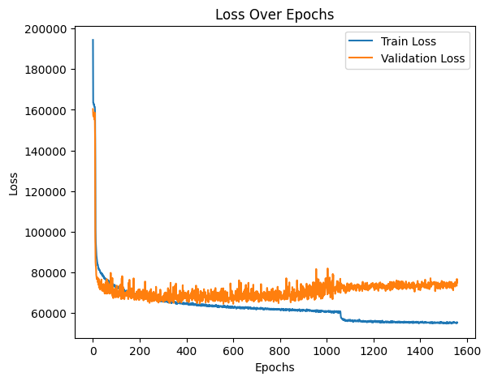

```python
# Representación del acc-loss
plot_history(best_dnn_history)
```

```python
best_dnn_model = load_model('./best_dnn_model.h5')
dnn_time = 2836.493649482727
```

```python
dnn_metrics = evaluacion(best_dnn_model, X_test, y_test)
dnn_metrics['Tiempo de entrenamiento'] = dnn_time
```

```
MSE: 16499605363.07016
RMSE: 128450.78965530013
MAE: 60403.09884096031
R²: 0.9156771003350932
MAPE: 15.626751439134287 %
```

```python
mse = best_dnn_model.evaluate(X_test, y_test, verbose=1)
```

Esta es la gráfica para el modelo DNN. La pérdida disminuye de forma continua tanto para el entrenamiento como para la validación al principio, sin embargo, cerca de las 200 epochs se estabiliza para la varianza. A partir de aquí podemos ver sobre entrenamiento, ya que la línea de la pérdida del conjunto de validación queda cada vez más por encima que la del entrenamiento. La fluctuación en la pérdida de la validación impidió que el EarlyStopping actuase antes, empeorando así los resultados.

## CNN

```python
# Redimensionamos X
X = np.expand_dims(X, axis=1)

input_shape = X.shape[1:]
```

```python
# Dividimos los datos en conjuntos de entrenamiento y prueba
X_train, X_test, y_train, y_test = train_test_split(X, y, test_size=0.1, shuffle=True, random_state=42)
X_train, X_val, y_train, y_val = train_test_split(X_train, y_train, test_size=0.1, shuffle=True, random_state=42)
```

```python
# ModelCheckpoint
model_checkpoint = ModelCheckpoint('best_cnn_model.h5', monitor='val_loss', save_best_only=True, verbose=0)
```

```python
# Compilamos el modelo
best_cnn_model.compile(optimizer=Adam(learning_rate=best_cnn_params['learning_rate']), loss='mae')

# Entrenamos el modelo
start_time = time.time()
best_cnn_history = best_cnn_model.fit(X_train, y_train, epochs=n, batch_size=256, validation_data=(X_val, y_val),
               verbose=0, callbacks=[tqdm_callback, early_stopping, reduce_lr, model_checkpoint])
end_time = time.time()
cnn_time = end_time - start_time

print(f'Tiempo de entrenamiento: {cnn_time}')
```

```
Epoch 1299: ReduceLROnPlateau reducing learning rate to 0.0059813115745782856.
```

```
Tiempo de entrenamiento: 1618.452129125595
```

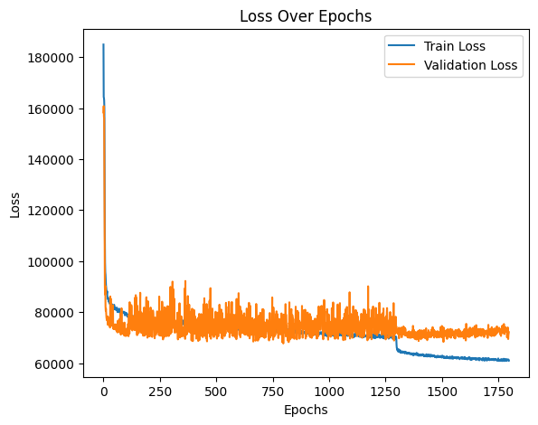

```python
# Representación del acc-loss
plot_history(best_cnn_history)
```

```python
best_cnn_model = load_model('./best_cnn_model.h5')
cnn_time = 1618.452129125595
```

```python
cnn_metrics = evaluacion(best_cnn_model, X_test, y_test)
cnn_metrics['Tiempo de entrenamiento'] = cnn_time
```

```
MSE: 18007638590.718296
RMSE: 134192.54297731412
MAE: 64193.60209900831
R²: 0.9079701442141344
MAPE: 16.354499052065822 %
```

```python
mse_cnn = best_cnn_model.evaluate(X_test, y_test, verbose=1)
```

Esta es la gráfica para el modelo CNN. Es un caso análogo a lo visto en la gráfica anterior, aunque esta vez se puede ver que el sobreajuste será menor puesto que ambas líneas descienden de forma más pareja hasta que la de validación empieza a fluctuar.

## Transformers

```python
# ModelCheckpoint
model_checkpoint = ModelCheckpoint('best_t_model.h5', monitor='val_loss', save_best_only=True, verbose=0)
```

```python
# Compilamos el modelo
best_t_model.compile(optimizer=Adam(learning_rate=best_t_params['learning_rate']), loss='mae')

# Entrenamos el modelo
start_time = time.time()
best_t_history = best_t_model.fit(X_train, y_train, epochs=n, batch_size=256, validation_data=(X_val, y_val),
               verbose=0, callbacks=[tqdm_callback, early_stopping, reduce_lr, model_checkpoint])
end_time = time.time()
t_time = end_time - start_time

print(f'Tiempo de entrenamiento: {t_time}')
```

```
Epoch 1287: ReduceLROnPlateau reducing learning rate to 0.02212059199810028.
```

```
Epoch 3349: ReduceLROnPlateau reducing learning rate to 0.002212059125304222.
```

```
Epoch 5154: ReduceLROnPlateau reducing learning rate to 0.00022120592184364797.
```

```
Tiempo de entrenamiento: 7244.399193525314
```

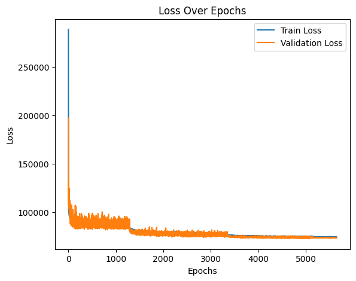

```python
# Representación del acc-loss
plot_history(best_t_history)
```

```python
best_t_model = load_model('./best_t_model.h5')
t_time = 7244.399193525314
```

```python
t_metrics = evaluacion(best_t_model, X_test, y_test)
t_metrics['Tiempo de entrenamiento'] = t_time
```

```
MSE: 21867160572.751537
RMSE: 147875.49010147536
MAE: 72161.17007162026
R²: 0.8882456673139829
MAPE: 18.386426773683322 %
```

```python
mse_t = best_t_model.evaluate(X_test, y_test, verbose=1)
```

### LSTM

```python
# ModelCheckpoint
model_checkpoint = ModelCheckpoint('best_lstm_model.h5', monitor='val_loss', save_best_only=True, verbose=0)
```

```python
# Compilamos el modelo
best_lstm_model.compile(optimizer=Adam(learning_rate=best_lstm_params['learning_rate']), loss='mae')

# Entrenamos el modelo
start_time = time.time()
best_lstm_history = best_lstm_model.fit(X_train, y_train, epochs=n, batch_size=256, validation_data=(X_val, y_val),
               verbose=0, callbacks=[tqdm_callback, early_stopping, reduce_lr, model_checkpoint])
end_time = time.time()
lstm_time = end_time - start_time

print(f'Tiempo de entrenamiento: {lstm_time}')
```

```
Epoch 1244: ReduceLROnPlateau reducing learning rate to 0.0007324858568608761.
```

```
Epoch 2660: ReduceLROnPlateau reducing learning rate to 7.32485845219344e-05.
```

```
Tiempo de entrenamiento: 4393.382444858551
```

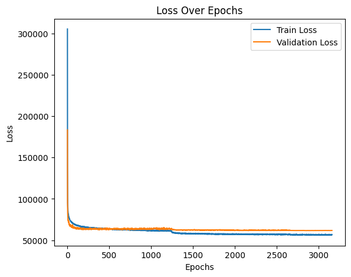

```python
# Representación del acc-loss
plot_history(best_lstm_history)
```

```python
best_lstm_model = load_model('./best_lstm_model.h5')
lstm_time = 4393.382444858551
```

```python
lstm_metrics = evaluacion(best_lstm_model, X_test, y_test)
lstm_metrics['Tiempo de entrenamiento'] = lstm_time
```

```
MSE: 14315092529.092932
RMSE: 119645.6958235144
MAE: 52952.65114768101
R²: 0.9268412738085057
MAPE: 14.258871365328185 %
```

```python
mse_lstm = best_lstm_model.evaluate(X_test, y_test, verbose=1)
```

Esta es la gráfica del modelo LSTM. Hasta el momento es la gráfica más prometedora ya que la línea de validación desciende de forma limpia y sin fluctuar. El escalón que podemos ver en las 1244 epochs en el entrenamiento, al igual que pasaba en las otras gráficas, se debe al callback ReduceOnPlateau, que reduce el learning rate cuando la validación deja de mejorar como un último intento de que esto ocurra antes del EarlyStopping, aunque podemos ver que no ha tenido mucho éxito.

# Conclusiones

Más allá de lo visto en las gráficas anteriores, se ha aplicado en el entrenamiento el callback ModelCheckpoint, que guarda el mejor modelo obtenido durante el entrenamiento para el conjunto de validación. Por lo que independientemente de que el entrenamiento haya sido eficiente o no, es necesario evaluar los resultados sobre el conjunto de test a partir de las métricas definidas anteriormente.

En esta presentación de los resultados también se visualizarán los obtenidos por los árboles de regresión, para tener una visión global de cuáles han resultado ser nuestros mejores modelos en el conjunto.

```python
metrics_rf = {'MSE': 9762372275.73786, 'RMSE': 98804.71788198102, 'MAE': 38982.20809414523, 'MedAE': 12674.149999999994, 'R2': 0.9501084104871381, 'MAPE': 9.979983423952707, 'Tiempo de entrenamiento': 170.4249472618103}
metrics_gb = {'MSE': 8844845133.512306, 'RMSE': 94047.03681409801, 'MAE': 30598.78977878564, 'MedAE': 6014.5462469922495, 'R2': 0.9547975256175449, 'MAPE': 8.047521585672204, 'Tiempo de entrenamiento': 234.8381278514862}
metrics_xgb = {'MSE': 8886464913.152782, 'RMSE': 94268.04820909777, 'MAE': 31357.605419907675, 'MedAE': 6829.921875, 'R2': 0.9545848235301027, 'MAPE': 8.37983323611406, 'Tiempo de entrenamiento': 33.34338736534119}
metrics_lgbm = {'MSE': 9343936627.569695, 'RMSE': 96664.03999197269, 'MAE': 36577.809421759586, 'MedAE': 12292.14818574686, 'R2': 0.9522468681290207, 'MAPE': 10.105932468710455, 'Tiempo de entrenamiento': 4.006396055221558}
```

```python
def comparar_metricas(modelos_metricas, nombres_modelos):
    metricas = ['MSE', 'RMSE', 'MAE', 'MedAE', 'R2', 'MAPE', 'Tiempo de entrenamiento']

    data = {metrica: [modelo[metrica] for modelo in modelos_metricas] for metrica in metricas}
    df = pd.DataFrame(data, index=nombres_modelos)

    # Iteramos sobre cada métrica y crear una gráfica de barras
    for metrica in metricas:
        # Obtenemos los valores para la métrica actual de cada modelo
        valores = [modelo[metrica] for modelo in modelos_metricas]

        # Creamos la gráfica de barras
        plt.figure(figsize=(10, 6))
        plt.bar(nombres_modelos, valores, color=['blue', 'green', 'red', 'purple'])
        plt.xticks(rotation=30)
        plt.title(f'Comparación de {metrica}')
        plt.ylabel(metrica)
        plt.xlabel('Modelos')
        for i, v in enumerate(valores):
            plt.text(i, v + max(valores)*0.01, f"{v:.2f}", ha='center')
        plt.show()

    return df
```

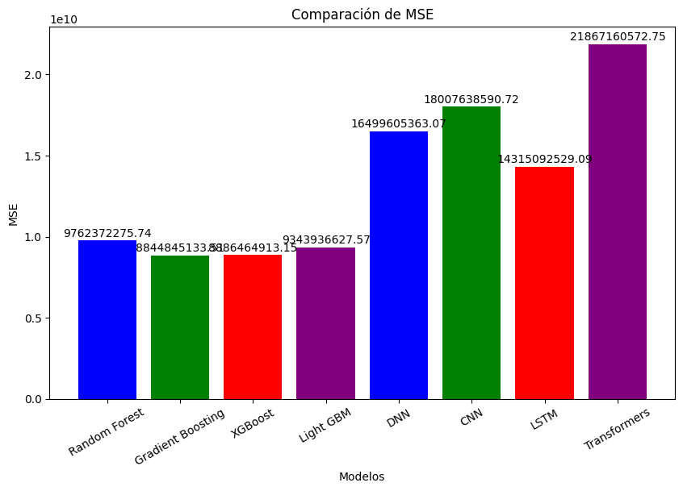

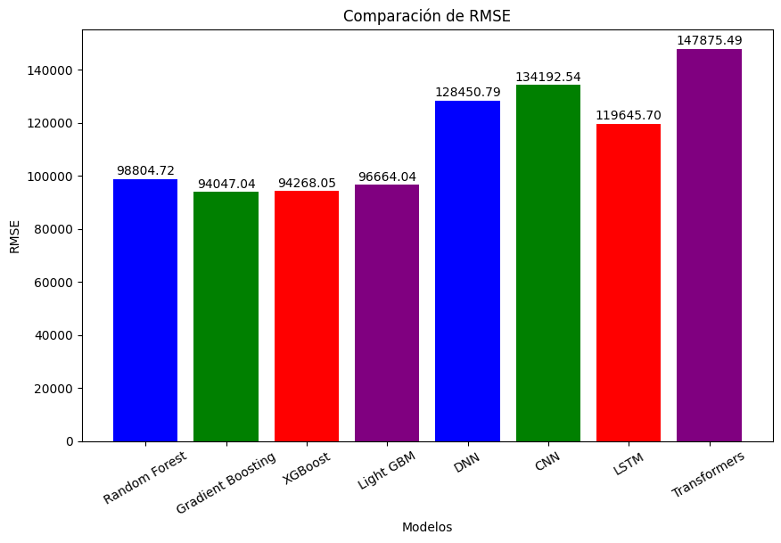

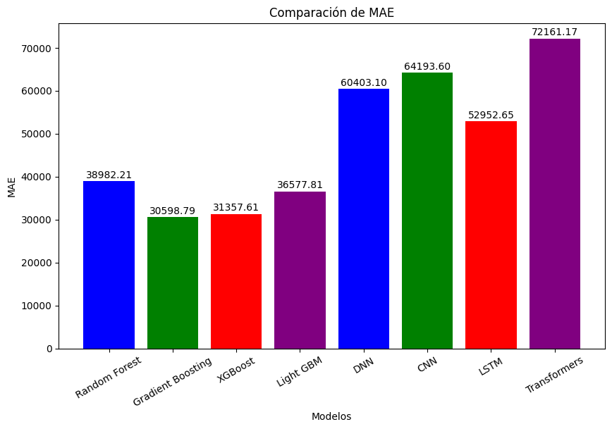

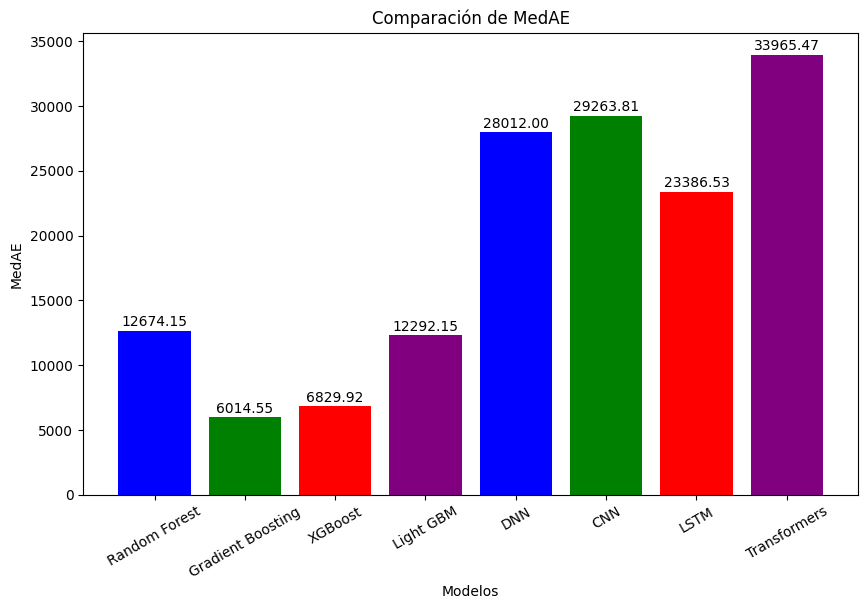

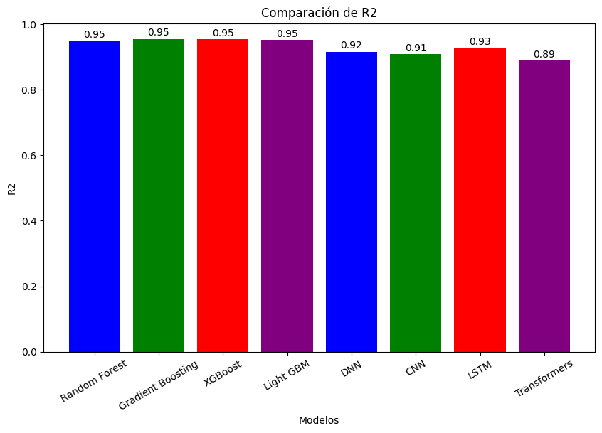

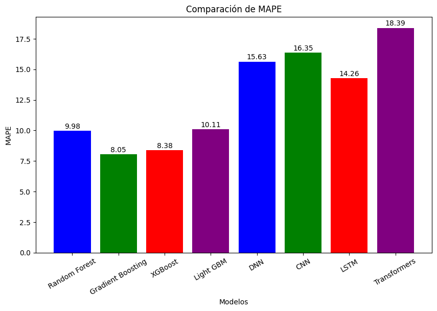

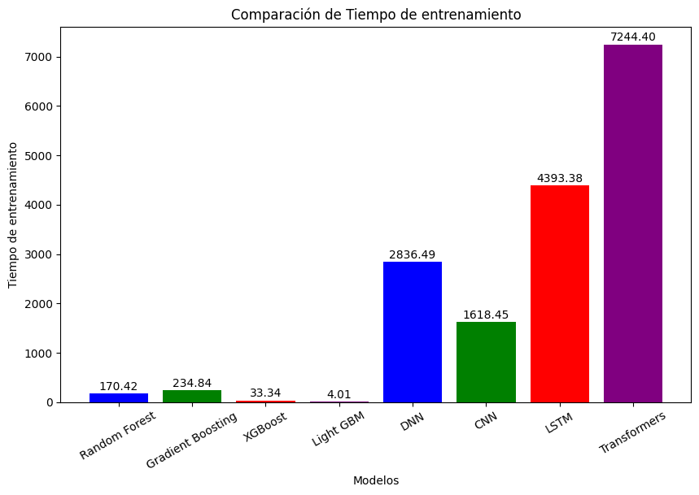

|  | MSE | RMSE | MAE | MedAE | R2 | MAPE | Tiempo de entrenamiento |
| --- | --- | --- | --- | --- | --- | --- | --- |
| Random Forest | 9.762372e+09 | 98804.717882 | 38982.208094 | 12674.150000 | 0.950108 | 9.979983 | 170.424947 |
| Gradient Boosting | 8.844845e+09 | 94047.036814 | 30598.789779 | 6014.546247 | 0.954798 | 8.047522 | 234.838128 |
| XGBoost | 8.886465e+09 | 94268.048209 | 31357.605420 | 6829.921875 | 0.954585 | 8.379833 | 33.343387 |
| Light GBM | 9.343937e+09 | 96664.039992 | 36577.809422 | 12292.148186 | 0.952247 | 10.105932 | 4.006396 |
| DNN | 1.649961e+10 | 128450.789655 | 60403.098841 | 28012.000000 | 0.915677 | 15.626751 | 2836.493649 |
| CNN | 1.800764e+10 | 134192.542977 | 64193.602099 | 29263.812500 | 0.907970 | 16.354499 | 1618.452129 |
| LSTM | 1.431509e+10 | 119645.695824 | 52952.651148 | 23386.531250 | 0.926841 | 14.258871 | 4393.382445 |
| Transformers | 2.186716e+10 | 147875.490101 | 72161.170072 | 33965.468750 | 0.888246 | 18.386427 | 7244.399194 |

```python
comparar_metricas([metrics_rf, metrics_gb, metrics_xgb, metrics_lgbm, dnn_metrics, cnn_metrics, lstm_metrics, t_metrics], ['Random Forest', 'Gradient Boosting', 'XGBoost', 'Light GBM', 'DNN', 'CNN', 'LSTM', 'Transformers'])
```

Como se aprecia a simple vista, el rendimiento de los modelos basados en árboles de regresión ha sido notablemente mejor que el obtenido mediante redes neuronales. Esto se puede explicar teniendo en cuenta lo comentado anteriormente, y es que este tipo de modelos está diseñado para conjuntos de datos masivos, lo cual a pesar de tener un tamaño considerable no es el caso de nuestro dataset.

En general todos los modelos han tendido ligeramente al sobreajuste ya que se han entrenado con una gran cantidad de epochs, sin embargo esto era necesario para obtener los mejores resultados posibles. En los modelos basados en árboles se ha conseguido controlar mejor el sobreajuste mediante técnicas de poda, mientras que la regulación L1-L2 y el Dropout no siempre han funcionado de manera óptima.

Con esto podemos concluir que los dos mejores modelos obtenidos son el basado en Gradient Boosting tradicional y el XGBoost.